# Midterm

Qianyi Yu

11/4/2024

```r
#1. Import data
library(fpp)
library(fpp2)
mydata <- read.csv("~/desktop/sales-2.csv",header = FALSE)
colnames(mydata) <- c("date", "sales")
mydata$date <- as.Date(mydata$date, format = "%m/%d/%y")
```

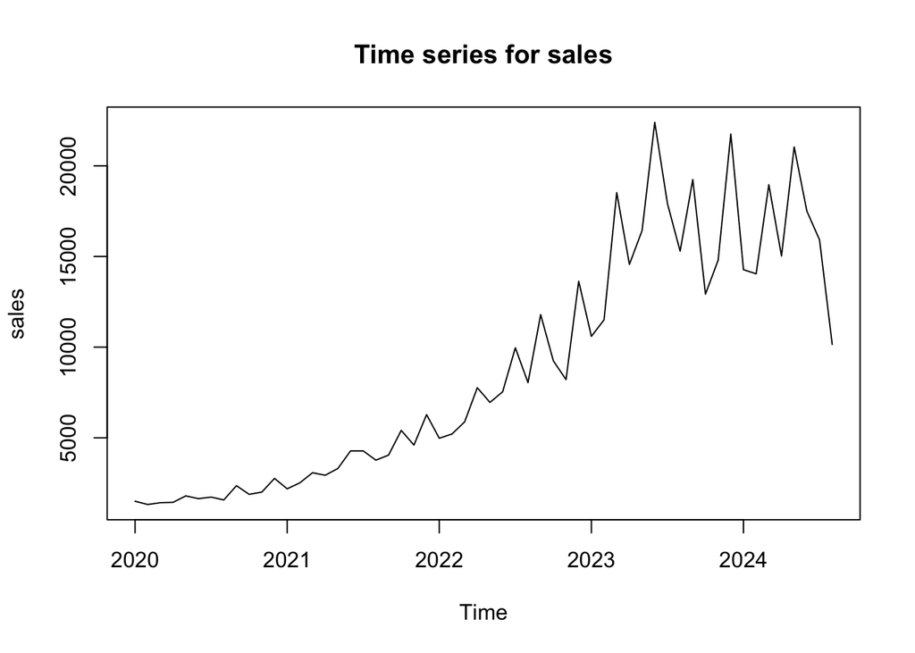

```r
#2. Plot and Inference
sales_ts <- ts(mydata$sales, start = c(2020,1), frequency = 12)
plot(sales_ts, main = "Time series for sales", ylab = "sales")
```

##### Summary: The time series plot shows a upwards seasonal trends with increasing volatility.

```r
#3. Central Tendency
summary(mydata$sales)
```

```
##    Min. 1st Qu.  Median    Mean 3rd Qu.    Max.
##    1322    2892    7246    8753   14346   22397
```

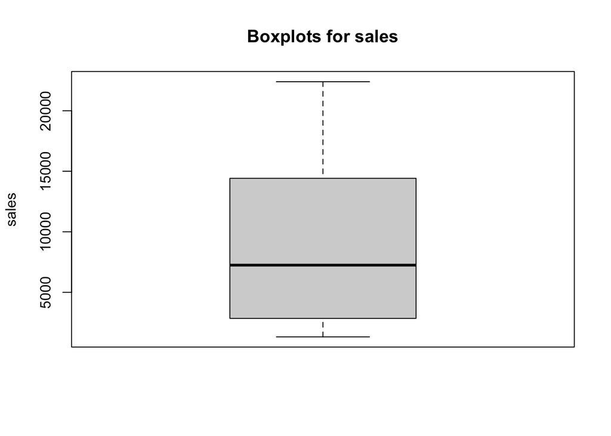

```r
boxplot(mydata$sales, main = "Boxplots for sales", ylab = "sales")
```

##### Summary: The min is 1322, the max is 22397, the mean is 8753, the median is 7246, the 1st quartile is 2892, and the 3rd quatile is 14346. The summarize stats and box plots shows that the sales is increasing over time and has a higher volatility in recent periods. The maximum value and the 3rd quatile value is much larger thant the median value indicates the recent values are larger than the previous.

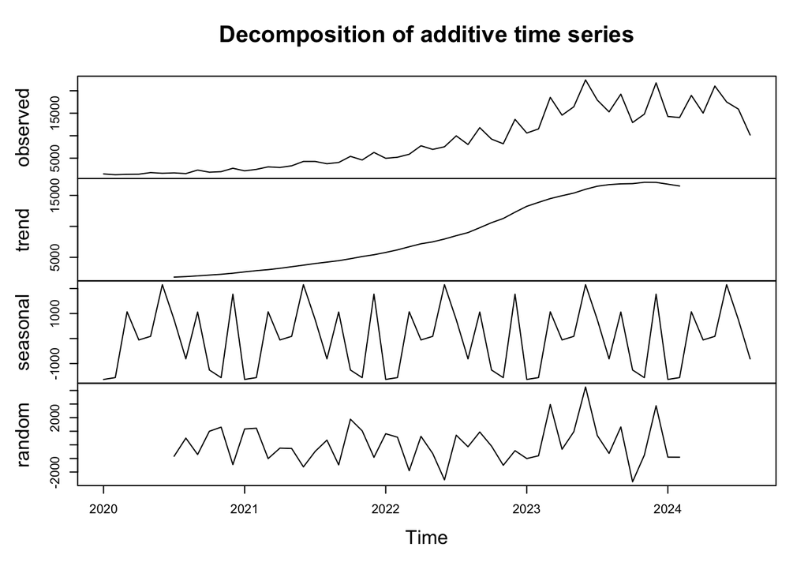

```r
#4. Decomposition
decomp <- decompose(sales_ts)
plot(decomp)
```

```r
seasonal_indices <- decomp$seasonal
print(seasonal_indices)
```

```
##              Jan         Feb         Mar         Apr         May         Jun
## 2020 -1637.61383 -1562.74459  1068.72820   -57.46680    87.83035  2154.71713
## 2021 -1637.61383 -1562.74459  1068.72820   -57.46680    87.83035  2154.71713
## 2022 -1637.61383 -1562.74459  1068.72820   -57.46680    87.83035  2154.71713
## 2023 -1637.61383 -1562.74459  1068.72820   -57.46680    87.83035  2154.71713
## 2024 -1637.61383 -1562.74459  1068.72820   -57.46680    87.83035  2154.71713
##              Jul         Aug         Sep         Oct         Nov         Dec
## 2020   753.35870  -814.83057  1059.15192 -1259.70934 -1565.32609  1773.90491
## 2021   753.35870  -814.83057  1059.15192 -1259.70934 -1565.32609  1773.90491
## 2022   753.35870  -814.83057  1059.15192 -1259.70934 -1565.32609  1773.90491
## 2023   753.35870  -814.83057  1059.15192 -1259.70934 -1565.32609  1773.90491
## 2024   753.35870  -814.83057
```

```r
seasadj(decomp)
```

```
##             Jan        Feb        Mar        Apr        May        Jun
## 2020  3139.4208  2884.9156   353.1618  1499.7218  1708.7687  -509.4441
## 2021  3825.3893  4079.2101  2006.0303  2992.5353  3220.3362  2123.3184
## 2022  6613.2438  6772.0181  4809.5218  7819.1698  6864.7062  5385.2759
## 2023 12232.8888 13070.7946 17454.9948 14622.2243 16341.6832 20242.0604
## 2024 15910.4603 15608.5736 17889.9408 15085.3153 20951.3832 15348.3979
##             Jul        Aug        Sep        Oct        Nov        Dec
## 2020   977.1373  2388.9226  1300.9966  3142.7448  3570.9526   988.0516
## 2021  3524.6768  4582.1446  2988.8206  6668.1853  6165.0571  4504.9136
## 2022  9210.6208  8859.3146 10731.9866 10504.9273  9774.5196 11860.7526
## 2023 17167.3428 16111.6751 18181.1046 14183.8163 16356.9866 19976.3171
## 2024 15166.0338 10966.7636
```

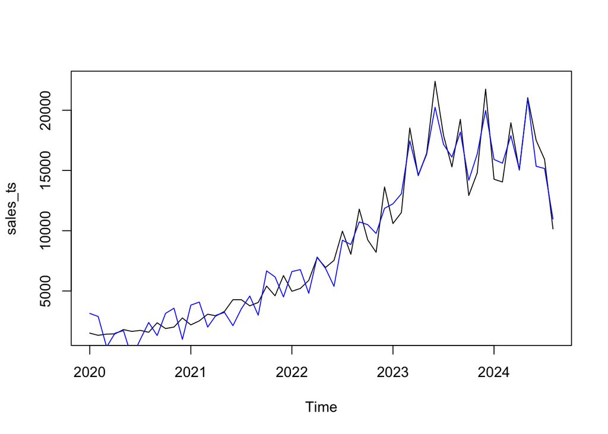

```r
plot(sales_ts)
lines(seasadj(decomp), col = "blue")
```

##### The seasonal conponent trend in decomposition shows repeating patterns, thus the time series is seasonal. The decomposition is additive shown in the title of the graph. The seasonal monthly indices are printed and June is the time series value high, January is the time series value low. The possible reason for June might be it’s the start of summer, people might stokcing medicine for alergies or other summer-related health needs. For January, people may have already stock enough medicine at the end of the year. The seasonality have big fluctuations in the value of time series.

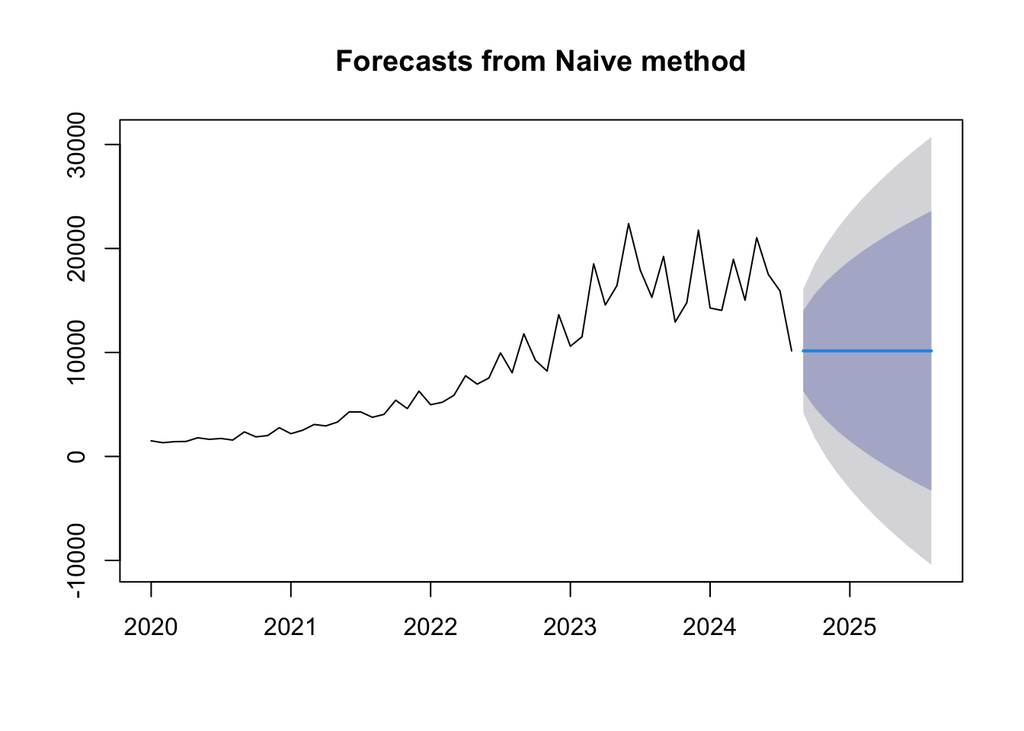

```r
#5. Naive Method
naive_forecast <- naive(sales_ts, h = 12)
plot(naive_forecast)
```

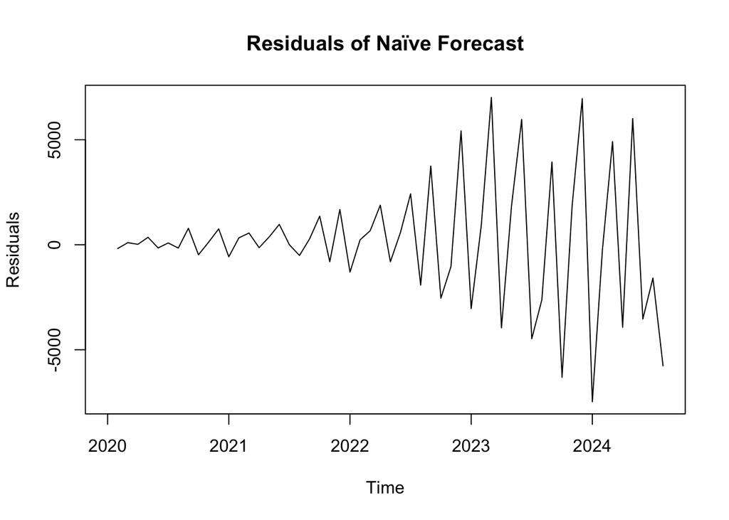

```r
#plot residual: shows increasing variability, especially in the last several periods. The patterns show that this method may not be able to capture the sales data's increasing trend, and which lead to a larger redisual over time.
plot(naive_forecast$residuals, main="Residuals of Naïve Forecast", ylab="Residuals", xlab="Time")
```

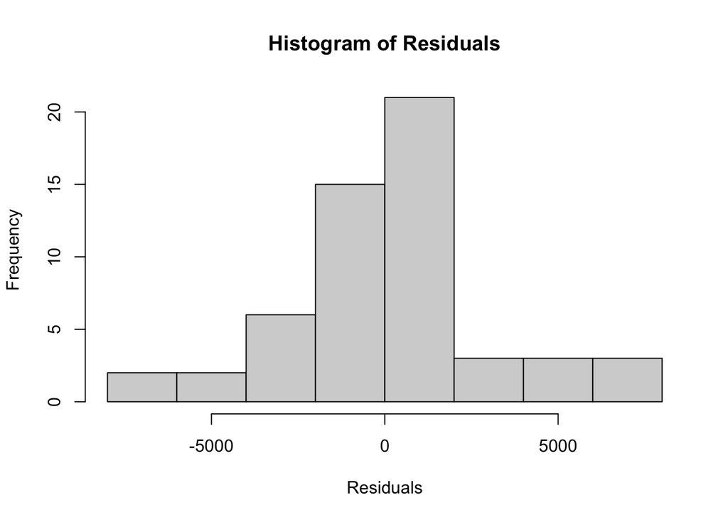

```r
#histogram plot for residual: residuals are centered around zero, but skewed toward the positive side. This means that the predicted values are underestimated than the actual values.
hist(naive_forecast$residuals, main="Histogram of Residuals", xlab="Residuals")
```

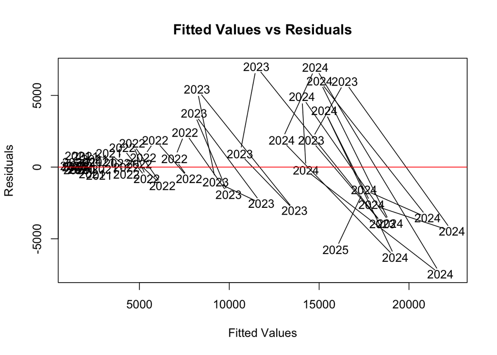

```r
#fitted values vs. residuals: this plot shows the residuals increase with the fitted values. The naïve method is not capturing the trend.
plot(fitted(naive_forecast), naive_forecast$residuals, main="Fitted Values vs Residuals", xlab="Fitted Values", ylab="Residuals")
abline(h=0, col="red")
```

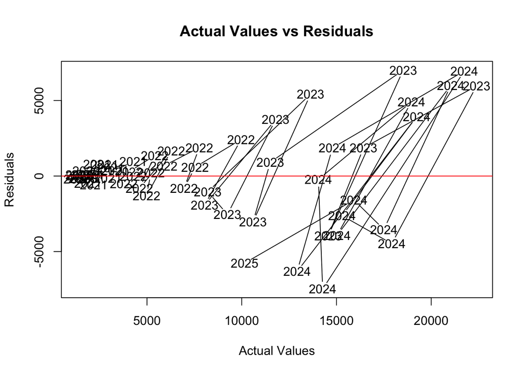

```r
#actual values vs. residuals: The residuals is increasing with the actual values, showing naïve method is not capturing the trends.
plot(sales_ts, naive_forecast$residuals, main="Actual Values vs Residuals", xlab="Actual Values", ylab="Residuals")
abline(h=0, col="red")
```

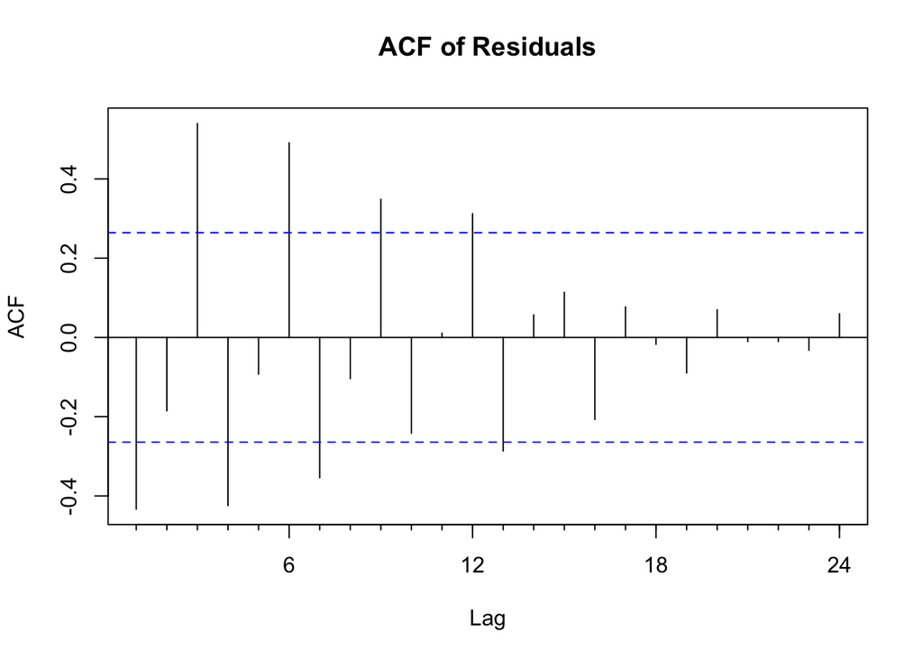

```r
#acf plot for residual: There are some significant autocorrelations for certain lags. This means naïve method does not capture all patterns in the data.
Acf(naive_forecast$residuals, main="ACF of Residuals")
```

```r
#five measures of accuracy: the high RMSE and MAPE values shows the naïve method is not very accuracy.
accuracy(naive_forecast)
```

```
##                   ME    RMSE      MAE       MPE     MAPE      MASE      ACF1
## Training set 157.275 3029.52 2104.495 0.6371928 20.12969 0.4670533 -0.433312
```

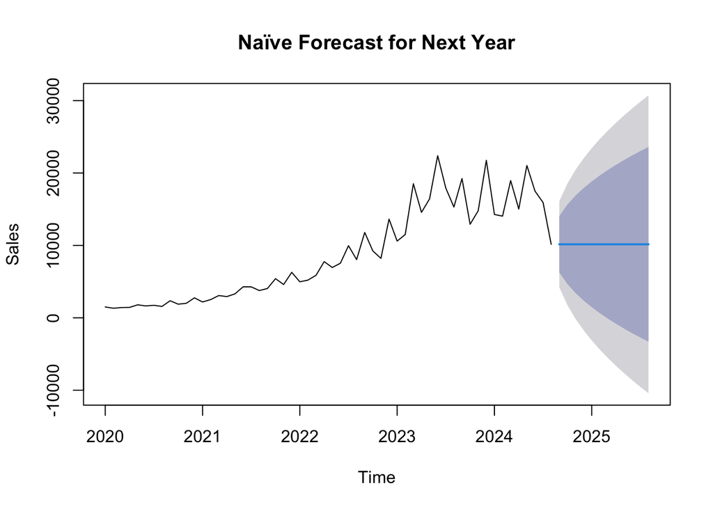

```r
#forecast: the forecast for the next year stay the same as the last observed value. This method does not capture the increasing trends and seasonality, it's forecast will result in errors.
plot(naive_forecast, main="Naïve Forecast for Next Year", xlab="Time", ylab="Sales")
```